# BMW VS Volskwagen II

Sara Bengoechea Rodríguez

12/13/2020

El objetivo del presente informe es estudiar la evolución del valor de las empresas BMW y Volkswagen en caso de no haberse producido el intento de fraude de Volkswagen referente a las emisiones de gases contaminantes en septiembre de 2015.

Dicho estudio lo llevaremos a cabo utilizando el modelo de Causal Impactact desarrollado por Google.

A continuación se muestra la evolución de ambas empresas desde Enero de 2014 hasta Noviembre de 2020. Es destacable la bajada de valor que supuso a la empresa de Volkswagen y, aunque en menor medida, como afectó también a BMW.

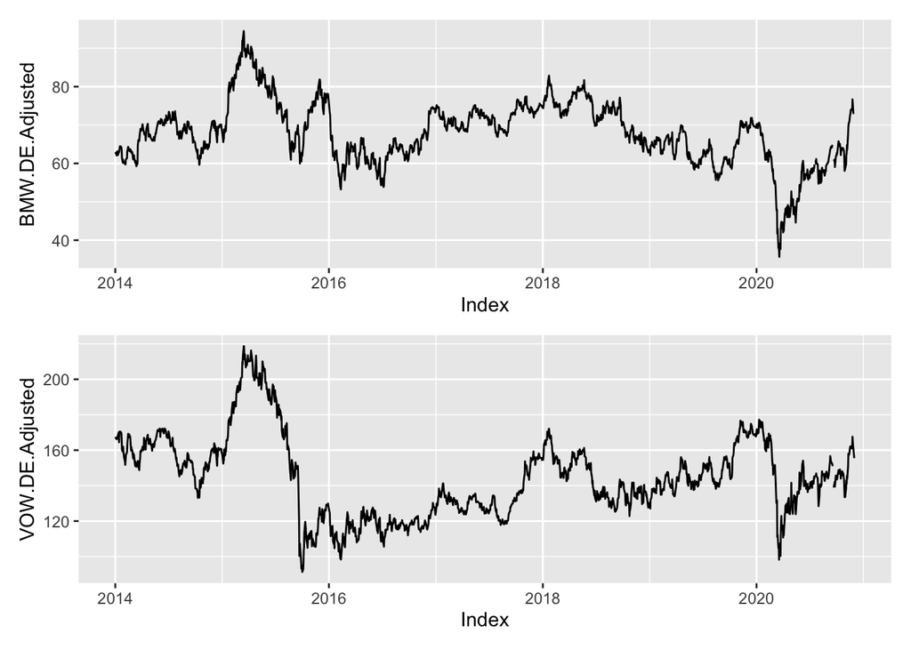

Mediante la función de CausalImpact y tras dividir nuestros datos en “antes” y “después” de la intevención, podemos obtener modelos para conocer cómo habría evolucionado el valor de cada empresa si no hubiese ocurrido el dieselgate. Los resultados son los siguientes:

Para BMW, su valor de media habría sido 63 en vez de 67, es decir, el hecho de que su principal competidor cometiese fraude, hizo que el valor de BMW fuese ligeramente superior que en una situación sin intervenciones. En promedio, el efecto causal estimado de este hecho fue de un aumento de 3,3 y generó un efecto relativo del 5.1%.

```
## Posterior inference {CausalImpact}
##
##                          Average       Cumulative
## Actual                   67            87331
## Prediction (s.d.)        63 (6.7)      83064 (8734.7)
## 95% CI                   [51, 78]      [66501, 101785]
##
## Absolute effect (s.d.)   3.3 (6.7)     4267.3 (8734.7)
## 95% CI                   [-11, 16]     [-14454, 20831]
##
## Relative effect (s.d.)   5.1% (11%)    5.1% (11%)
## 95% CI                   [-17%, 25%]   [-17%, 25%]
##
## Posterior tail-area probability p:   0.29392
## Posterior prob. of a causal effect:  71%
##
## For more details, type: summary(impact, "report")
```

En la gráfica que se muestra, la línea vertical representa el momento de la intevención, la línea negra representa la evolución real del valor de BMW y la azul, la estimación en caso de no haberse producido el fraude.

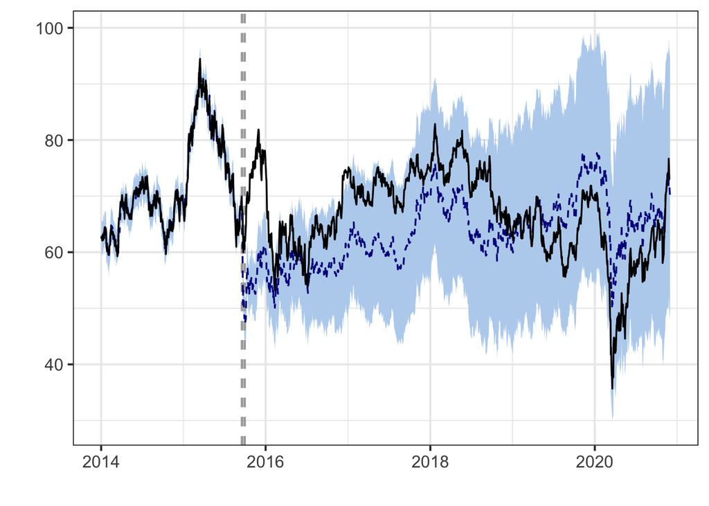

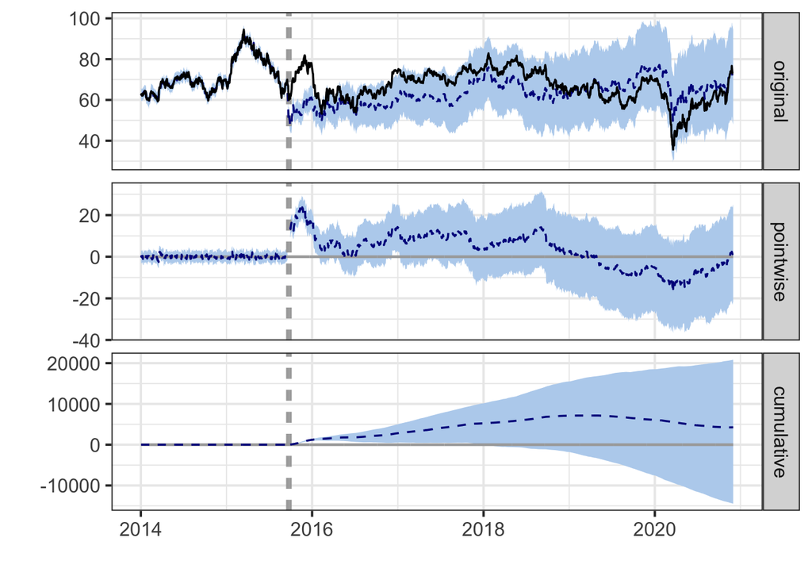

```
## Posterior inference {CausalImpact}
##
##                          Average       Cumulative
## Actual                   136           178652
## Prediction (s.d.)        147 (16)      192321 (21123)
## 95% CI                   [116, 181]    [151752, 237226]
##
## Absolute effect (s.d.)   -10 (16)      -13669 (21123)
## 95% CI                   [-45, 21]     [-58574, 26900]
##
## Relative effect (s.d.)   -7.1% (11%)   -7.1% (11%)
## 95% CI                   [-30%, 14%]   [-30%, 14%]
##
## Posterior tail-area probability p:   0.25451
## Posterior prob. of a causal effect:  75%
##
## For more details, type: summary(impact, "report")
```

Su representación gráfica sería como se muestra a continuación

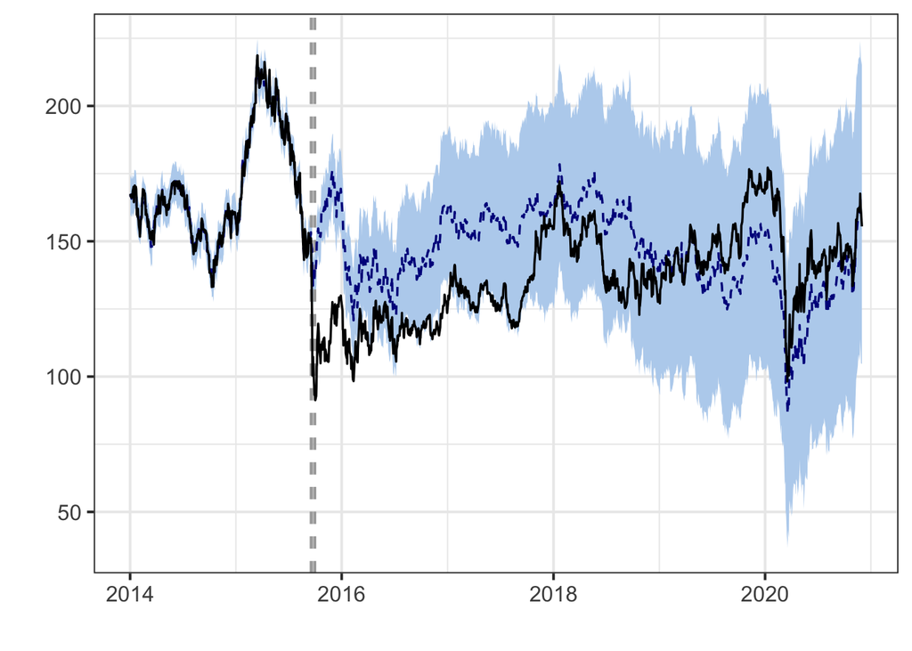

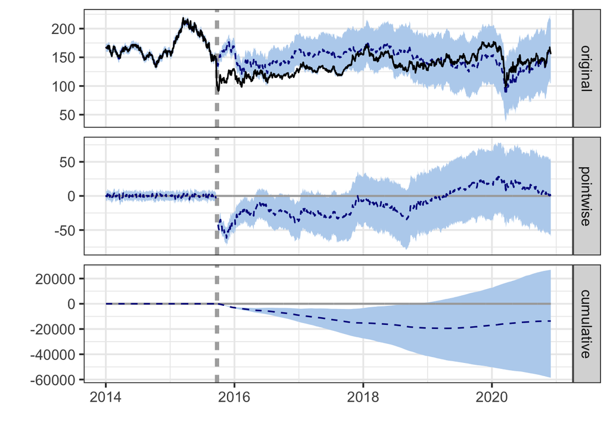

De manera atomática podemos generar un informe con las conclusiones recientement comentadas.

[output not shown]

[output not shown]